# MiniProj2

2024-11-28

```r
rm(list = ls())
library(GGally)
library(dplyr)
```

```r
library(corrplot)
library(leaps)
library("RColorBrewer")
library(car)
source("resFigs.R")
```

```r
used_cars <- read.csv("usedCars.csv")


#Price difference between Automatic vs manual
aggregate(Price ~ Transmission, data = used_cars, FUN = mean)
```

```
##   Transmission   Price
## 1    Automatic 2142453
## 2       Manual  800000
```

```r
#Price difference between Automatic vs manual
aggregate(Price ~ FuelType, data = used_cars, FUN = mean)
```

```
##   FuelType   Price
## 1   Diesel 1759091
## 2   Petrol 1379000
```

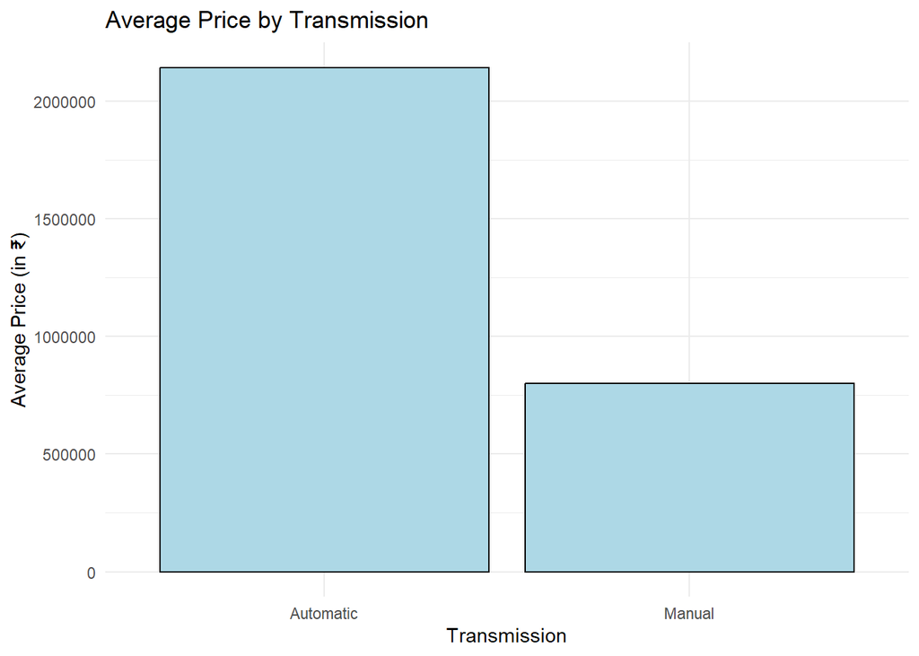

```r
# Bar plot for Transmission
ggplot(used_cars, aes(x = Transmission, y = Price)) +
  stat_summary(fun = mean, geom = "bar", fill = "lightblue", color = "black") +
  labs(title = "Average Price by Transmission", x = "Transmission", y = "Average Price (in ₹)") +
  theme_minimal()
```

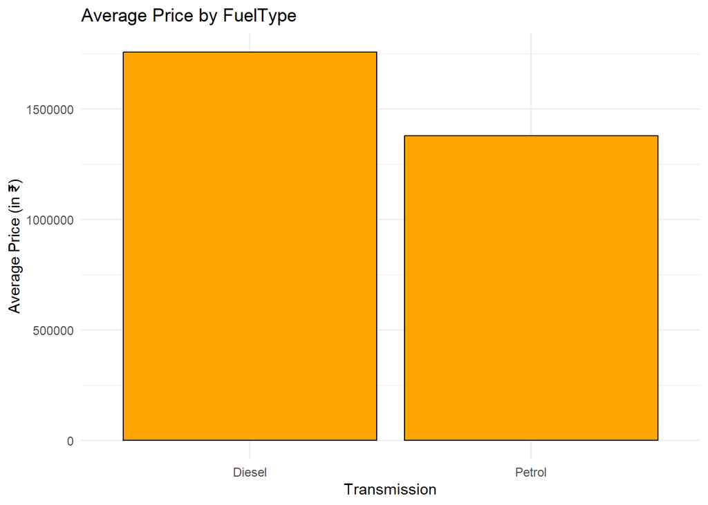

```r
ggplot(used_cars,
       aes(x = FuelType,
           y = Price)) +
  stat_summary(fun = "mean", geom = "bar", fill = "orange", color = "black") +
  labs(title = "Average Price by FuelType", x = "Transmission", y = "Average Price (in ₹)") +
  theme_minimal()
```

```r
#indicator variable for transmission, 1 = Automatic, 0 = Manual
used_cars$Transmission <- ifelse(used_cars$Transmission == "Automatic", 1,0)
#indicator variable for FuelType, 1 = Petrol, 0 = Diesel
used_cars$FuelType <- ifelse(used_cars$FuelType == "Petrol", 1, 0)

#Dropping carID variable
used_cars <- select(used_cars, -1)
head(used_cars)
```

```
##   KmDriven FuelType Transmission Mileage Engine Power Age Seats   Price
## 1    50000        1            0      15   1498   108   6     5  800000
## 2    40000        1            1      17   1597   140   5     5 1000000
## 3    20000        1            1      10   4951   395   7     4 2500000
## 4    30000        0            0      23   1248    74   4     5  600000
## 5    60000        0            1      18   1999   194   8     5  850000
## 6    35000        1            0      17   1198   108   5     5  750000
```

```r
#training/testing split

set.seed(3265)
train_ind <- sample(1:nrow(used_cars), floor(0.8 *nrow(used_cars)))
set.seed(NULL)

train <- used_cars[train_ind, ]
test <- used_cars[-train_ind, ]
```

# Checking which vandidate predictors wil cause high influential points

```r
#correlation matrix of every variable

correlation_matrix <- cor(train, method = "pearson")
correlation_matrix
```

```
##                 KmDriven    FuelType Transmission    Mileage     Engine
## KmDriven      1.00000000 -0.35502956  -0.03773728 -0.1154257  0.1128402
## FuelType     -0.35502956  1.00000000  -0.10021498 -0.0524845 -0.3150092
## Transmission -0.03773728 -0.10021498   1.00000000 -0.2467479  0.3751636
## Mileage      -0.11542565 -0.05248450  -0.24674786  1.0000000 -0.6536206
## Engine        0.11284018 -0.31500923   0.37516362 -0.6536206  1.0000000
## Power        -0.05334213 -0.06327289   0.55156617 -0.6219361  0.7782651
## Age           0.73012793 -0.21655335   0.17542360 -0.2016031  0.3446442
## Seats         0.41069809 -0.34635360  -0.13641201 -0.2620109  0.2094578
## Price        -0.09535213 -0.22681270   0.66060513 -0.5525840  0.6813561
##                    Power        Age        Seats        Price
## KmDriven     -0.05334213  0.7301279  0.410698088 -0.095352130
## FuelType     -0.06327289 -0.2165534 -0.346353595 -0.226812699
## Transmission  0.55156617  0.1754236 -0.136412010  0.660605134
## Mileage      -0.62193606 -0.2016031 -0.262010875 -0.552583979
## Engine        0.77826510  0.3446442  0.209457831  0.681356082
## Power         1.00000000  0.2179025 -0.115297667  0.825842154
## Age           0.21790248  1.0000000  0.179904775  0.160415506
## Seats        -0.11529767  0.1799048  1.000000000  0.002879681
## Price         0.82584215  0.1604155  0.002879681  1.000000000
```

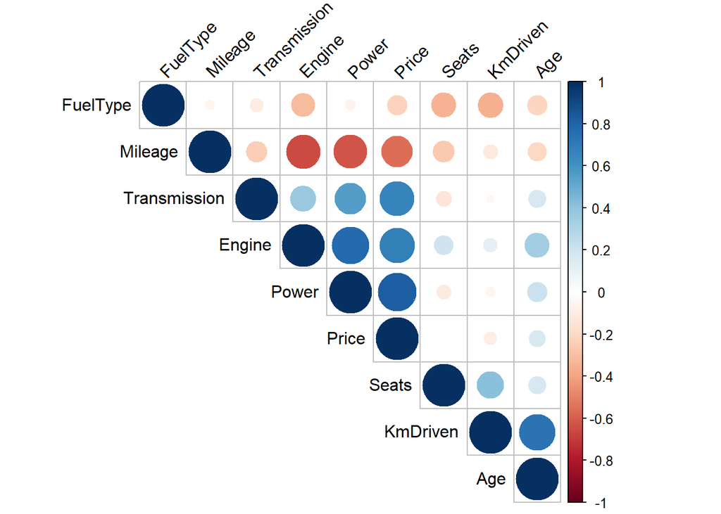

```r
cor <- cor(train)
corrplot(cor, type = "upper", order = "hclust", tl.col = "black", tl.srt = 45)
```

```r
correlation_matrix["Price", ]
```

```
##     KmDriven     FuelType Transmission      Mileage       Engine        Power
## -0.095352130 -0.226812699  0.660605134 -0.552583979  0.681356082  0.825842154
##          Age        Seats        Price
##  0.160415506  0.002879681  1.000000000
```

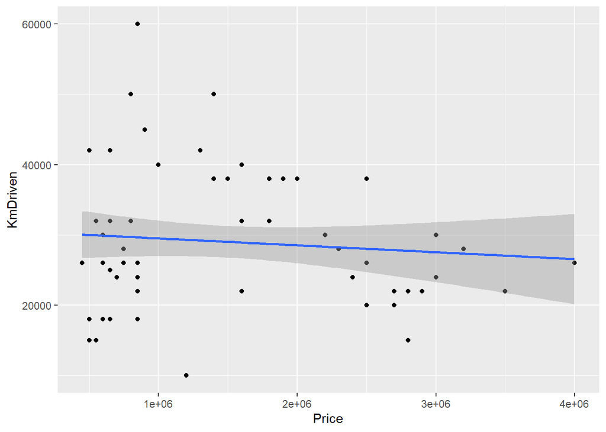

```r
# Visualize relationships
ggplot(train, aes(x = Price, y = KmDriven)) + geom_point() + geom_smooth(method = "lm")
```

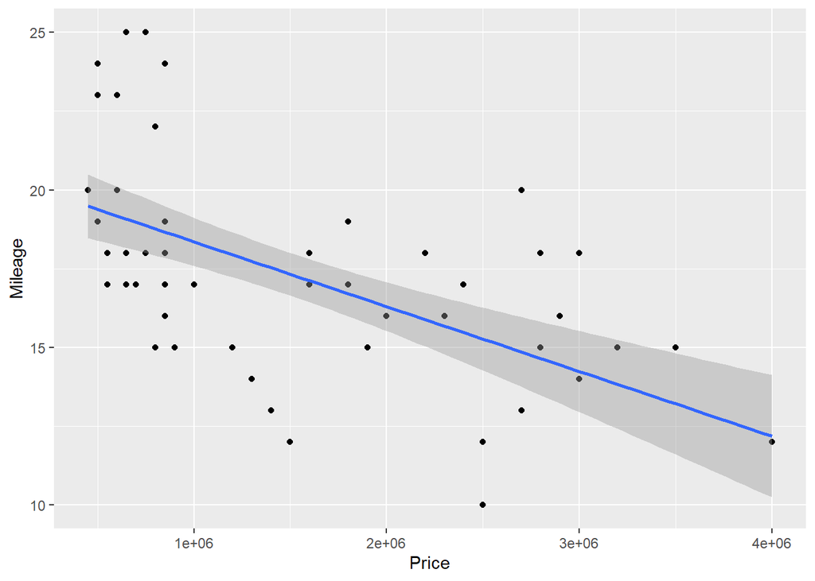

```r
ggplot(train, aes(x = Price, y = Mileage)) + geom_point() + geom_smooth(method = "lm")
```

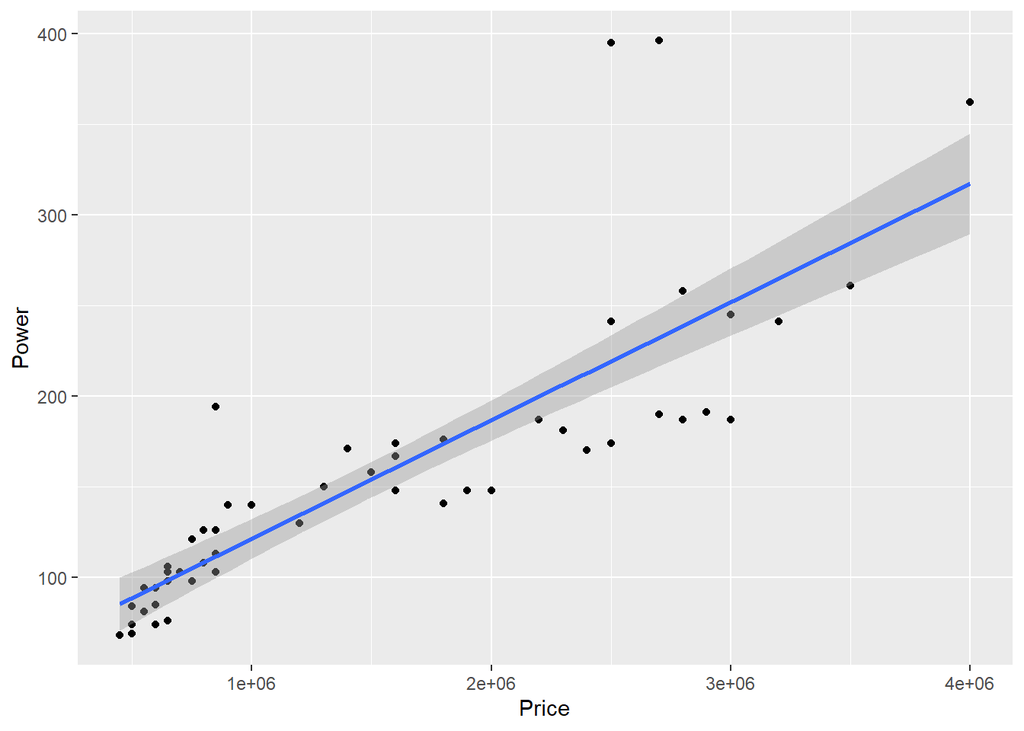

```r
ggplot(train, aes(x = Price, y= Power)) + geom_point() + geom_smooth(method=  "lm")
```

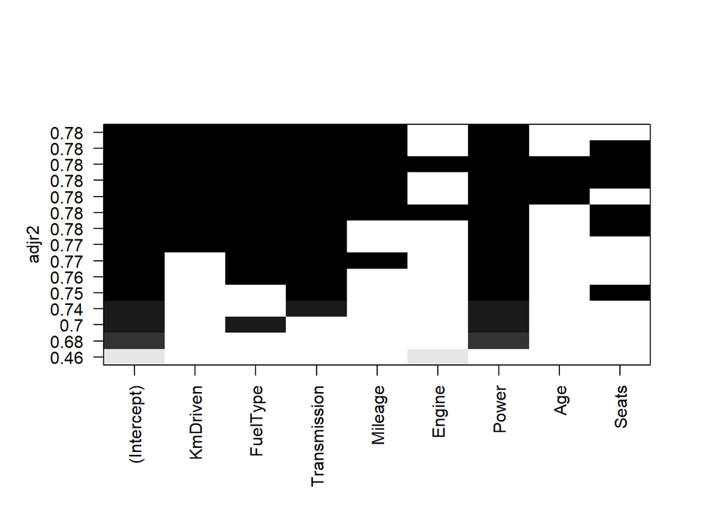

```r
library(leaps); library("RColorBrewer")
bestfits <- regsubsets(Price ~ KmDriven + FuelType + Transmission + Mileage + Engine + Power + Age + Seats ,
                       data = train, nbest = 2)
plot(bestfits, scale="adjr2")
```

Based on the bestfits, we remove the following candidate predictors: Engine Age Seats

# 5% TEST

```r
#used_cars$Price <- log(used_cars$Price)
#Full Regression Model
full_model <- lm(Price ~ KmDriven + FuelType + Transmission + Mileage + Engine + Power + Age + Seats , data = train)


summary(full_model)
```

```
##
## Call:
## lm(formula = Price ~ KmDriven + FuelType + Transmission + Mileage +
##     Engine + Power + Age + Seats, data = train)
##
## Residuals:
##     Min      1Q  Median      3Q     Max
## -890325 -172971   36507  243604  885926
##
## Coefficients:
##                Estimate Std. Error t value Pr(>|t|)
## (Intercept)   1.059e+06  9.015e+05   1.175  0.24431
## KmDriven     -2.509e+01  9.541e+00  -2.630  0.01062 *
## FuelType     -4.592e+05  1.348e+05  -3.407  0.00112 **
## Transmission  5.400e+05  1.264e+05   4.273 6.34e-05 ***
## Mileage      -4.799e+04  2.331e+04  -2.059  0.04345 *
## Engine       -1.726e+02  1.684e+02  -1.025  0.30932
## Power         7.706e+03  1.442e+03   5.345 1.21e-06 ***
## Age           8.056e+04  7.393e+04   1.090  0.27982
## Seats         1.197e+05  9.281e+04   1.290  0.20170
## ---
## Signif. codes:  0 '***' 0.001 '**' 0.01 '*' 0.05 '.' 0.1 ' ' 1
##
## Residual standard error: 441300 on 66 degrees of freedom
## Multiple R-squared:  0.806,  Adjusted R-squared:  0.7825
## F-statistic: 34.29 on 8 and 66 DF,  p-value: < 2.2e-16
```

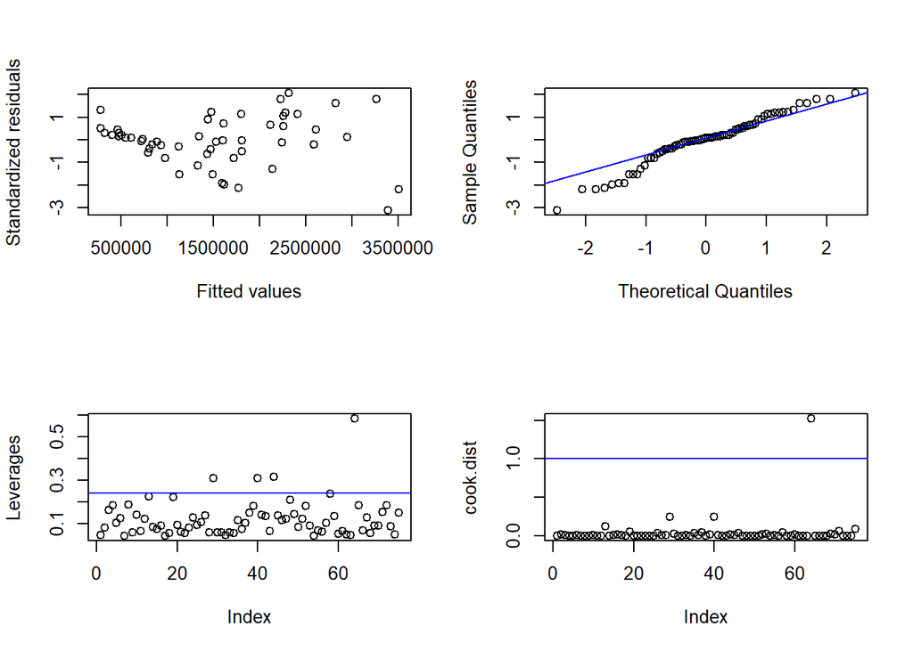

```r
res.figs(full_model)
```

Hypothesis:

Null: $H_0$: $\beta_i$ = 0 Alternate: $H_1$: $\beta_i$ != 0

Based on the test we reject Null Hyothesis if p-value < 0.05; therefore, we remove the following candidate predictors at 5%: Engine Age Seats

# Forward selection

```r
#null Model
null_model <- lm(Price ~ 1, data = train)

forward_model <- step(null_model, scope = formula(full_model), direction = "forward")
```

```
## Start:  AIC=2065.03
## Price ~ 1
##
##                Df  Sum of Sq        RSS    AIC
## + Power         1 4.5189e+13 2.1069e+13 1981.1
## + Engine        1 3.0760e+13 3.5498e+13 2020.2
## + Transmission  1 2.8915e+13 3.7343e+13 2024.0
## + Mileage       1 2.0232e+13 4.6027e+13 2039.7
## + FuelType      1 3.4086e+12 6.2850e+13 2063.1
## <none>                       6.6258e+13 2065.0
## + Age           1 1.7050e+12 6.4553e+13 2065.1
## + KmDriven      1 6.0242e+11 6.5656e+13 2066.3
## + Seats         1 5.4945e+08 6.6258e+13 2067.0
##
## Step:  AIC=1981.1
## Price ~ Power
##
##                Df  Sum of Sq        RSS    AIC
## + Transmission  1 4.0059e+12 1.7063e+13 1967.3
## + FuelType      1 2.0271e+12 1.9042e+13 1975.5
## + Seats         1 6.4620e+11 2.0423e+13 1980.8
## <none>                       2.1069e+13 1981.1
## + Engine        1 2.5079e+11 2.0818e+13 1982.2
## + KmDriven      1 1.7487e+11 2.0894e+13 1982.5
## + Mileage       1 1.6404e+11 2.0905e+13 1982.5
## + Age           1 2.6553e+10 2.1043e+13 1983.0
##
## Step:  AIC=1967.28
## Price ~ Power + Transmission
##
##            Df  Sum of Sq        RSS    AIC
## + FuelType  1 1.6145e+12 1.5449e+13 1961.8
## + Seats     1 9.6741e+11 1.6096e+13 1964.9
## + Engine    1 5.0598e+11 1.6557e+13 1967.0
## + Mileage   1 5.0099e+11 1.6562e+13 1967.0
## <none>                   1.7063e+13 1967.3
## + KmDriven  1 1.5857e+11 1.6905e+13 1968.6
## + Age       1 8.9664e+10 1.6974e+13 1968.9
##
## Step:  AIC=1961.83
```

[output cut: 13 more lines]

```
##           Df  Sum of Sq        RSS    AIC
## + Mileage  1 1.2357e+12 1.3367e+13 1955.0
## + Seats    1 8.0356e+11 1.3799e+13 1957.4
## <none>                  1.4603e+13 1959.6
## + Engine   1 7.5058e+10 1.4528e+13 1961.2
## + Age      1 3.6211e+10 1.4566e+13 1961.4
##
## Step:  AIC=1954.97
## Price ~ Power + Transmission + FuelType + KmDriven + Mileage
##
##          Df  Sum of Sq        RSS    AIC
## <none>                 1.3367e+13 1955.0
## + Seats   1 1.9027e+11 1.3177e+13 1955.9
## + Age     1 9.2587e+10 1.3274e+13 1956.5
## + Engine  1 4.2852e+10 1.3324e+13 1956.7
```

All three tests suggest that we remove the following predictors: Engine Age Seats

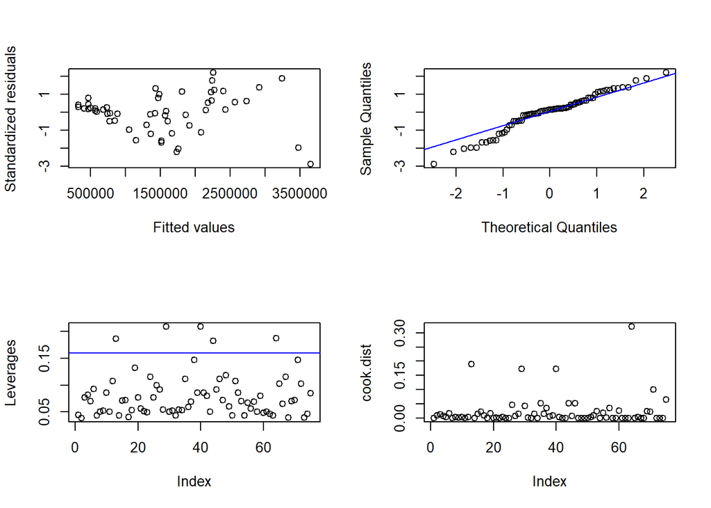

```r
res.figs(forward_model)
```

```r
anova(full_model, forward_model)
```

```
## Analysis of Variance Table
##
## Model 1: Price ~ KmDriven + FuelType + Transmission + Mileage + Engine +
##     Power + Age + Seats
## Model 2: Price ~ Power + Transmission + FuelType + KmDriven + Mileage
##   Res.Df        RSS Df   Sum of Sq      F Pr(>F)
## 1     66 1.2851e+13
## 2     69 1.3367e+13 -3 -5.1616e+11 0.8836 0.4542
```

Null: $H_0$ : $\beta_Engine$ = $\beta_Age$ = $\beta_Seats$ = 0 The additional predictors in the model do not significantly improve the models performance.

Alternate: $H_1$: $\beta_Engine$ = $\beta_Age$ = $\beta_Seats$ != 0 The additional predictors significantly improve the models performance.

Since p-value 0.4542 > 0.05, we fail to reject null hypothesis this means that difference in performance between full_model and reduced_model is not statistically significant.

# Interpreting the models

```r
summary(forward_model)
```

```
##
## Call:
## lm(formula = Price ~ Power + Transmission + FuelType + KmDriven +
##     Mileage, data = train)
##
## Residuals:
##      Min       1Q   Median       3Q      Max
## -1149763  -206746    62987   246070   943352
##
## Coefficients:
##                Estimate Std. Error t value Pr(>|t|)
## (Intercept)  1697546.39  535825.30   3.168 0.002287 **
## Power           6647.41    1047.73   6.345 2.00e-08 ***
## Transmission  560067.08  123988.29   4.517 2.52e-05 ***
## FuelType     -433050.15  111920.55  -3.869 0.000245 ***
## KmDriven         -15.42       5.82  -2.650 0.009970 **
## Mileage       -49203.76   19482.37  -2.526 0.013852 *
## ---
## Signif. codes:  0 '***' 0.001 '**' 0.01 '*' 0.05 '.' 0.1 ' ' 1
##
## Residual standard error: 440100 on 69 degrees of freedom
## Multiple R-squared:  0.7983, Adjusted R-squared:  0.7836
## F-statistic:  54.6 on 5 and 69 DF,  p-value: < 2.2e-16
```

Power  
6647.41 Positive For every unit increase in Power, the sale price increases by ₹6,647.41. Transmission  
560067.08 560067.08 Positive Cars with the alternate transmission (e.g., automatic vs manual) are worth ₹560,067 more.

KmDriven  
−15.42 Negative For every additional kilometer driven, the sale price decreases by ₹15.42. Mileage − 49203.76 −49203.76 Negative For every unit increase in mileage (fuel consumption), the sale price decreases by ₹49,203.76.

```r
vif(forward_model)
```

```
##        Power Transmission     FuelType     KmDriven      Mileage
##     2.345187     1.474949     1.206981     1.229123     1.796638
```

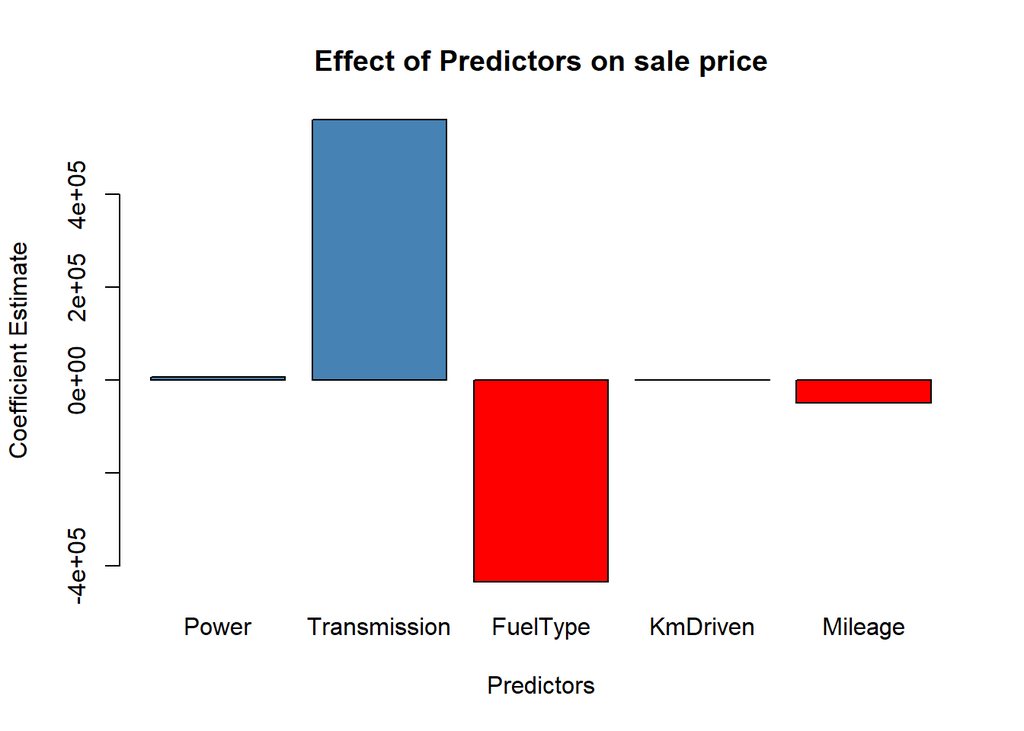

```r
# Extract coefficients
coeff <- coef(forward_model)
#Removing intercept
coeff <- coeff[-1]

#Plotting
barplot(coeff,
        xlab = "Predictors",
        ylab = "Coefficient Estimate",
        main = "Effect of Predictors on sale price",
        col = ifelse(coeff > 0, "steelblue", "red"))
```

# Prediciting the Prices

```r
test$Predicted_price <- predict(forward_model, newdata = test)
test$Residuals <- test$Price - test$Predicted_price
summary(test$Residuals)
```

```
##    Min. 1st Qu.  Median    Mean 3rd Qu.    Max.
## -692212 -277245  118591   74990  395198  943352
```

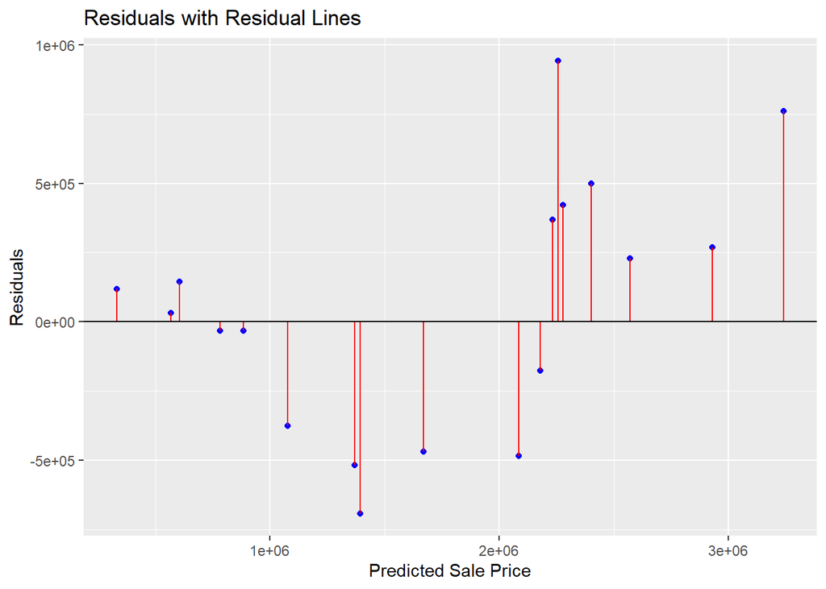

```r
# Residual Plot with Lines
ggplot(test, aes(x = Predicted_price, y = Residuals)) +
  geom_point(color = "blue") +  # Scatter plot of residuals
  geom_segment(aes(x = Predicted_price,
                   xend = Predicted_price,
                   y = 0,
                   yend = Residuals),
               color = "red") +  # Residual lines
  geom_hline(yintercept = 0, color = "black") +  # Zero residual line
  ggtitle("Residuals with Residual Lines") +
  xlab("Predicted Sale Price") +
  ylab("Residuals")
```

```r
MAE <- mean(abs(test$Residuals))
RMSE <- sqrt(mean(test$Residuals^2))
MAPE <- mean(abs(test$Residuals / test$Price)) * 100

cat(" MAE:", MAE, "\n", "RMSE:", RMSE, "\n", "MAPE:", MAPE, "\n")
```

```
##  MAE: 368185.1
##  RMSE: 444295.7
##  MAPE: 25.21134
```

The model’s predictions deviate by 25.21% from the actual car prices.

# Testing on newCars data

```r
newCars <- read.csv("newCars.csv")
newCarResults <- read.csv("newCarResults.csv")

#indicator variable for transmission, 1 = Automatic, 0 = Manual
newCars$Transmission <- ifelse(newCars$Transmission == "Automatic", 1,0)
#indicator variable for FuelType, 1 = Petrol, 0 = Diesel
newCars$FuelType <- ifelse(newCars$FuelType == "Petrol", 1, 0)
head(newCars, 4 )
```

```
##   carID KmDriven FuelType Transmission Mileage Engine Power Age Seats   Price
## 1  MS44    15000        1            1      18   1462   103   4     5  700000
## 2  BX48    28000        1            1      14   2998   335   6     5 3200000
## 3  MX54    26000        0            0      20   1497   115   5     5  700000
## 4  AA56    28000        0            1      17   1968   187   6     5 2600000
```

```r
newCars$PredPrice <- predict(forward_model, newdata = newCars)
# Calculate prediction intervals
prediction_intervals <- predict(forward_model, newdata = newCars, interval = "prediction")


# Add intervals to the newCars dataset
newCars$LowPrice <- prediction_intervals[, "lwr"]  # Lower bound of interval
newCars$HighPrice <- prediction_intervals[, "upr"] # Upper bound of interval


# Select only the required columns
newCarResults <- newCars[, c("carID", "PredPrice", "LowPrice", "HighPrice")]

# Save to newCarResults.csv
write.csv(newCarResults, "newCarResults.csv", row.names = FALSE)
```